# Severe Weather Events: Tornados most harmful while Floods have the greatest economic consequences

## Synopsis

Storms and other severe weather events can cause both public health and economic problems for communities and municipalities. Many severe events can result in fatalities, injuries, and property damage, and preventing such outcomes to the extent possible is a key concern.

We studied the U.S. National Oceanic and Atmospheric Administration’s (NOAA) storm database in order to find out which types of events are most harmful to the population health and which types of events have the greatest economic consequences.

We hope that our findings will help you prepare for the server weather events in order to minimize their impact on the population and the economy.

## Data Processing

### Loading Necessary Libraries

```r
library(ggplot2)
library(dplyr)
```

### Downloading and Reading the data from the file

```r
destFile<-"repdata_data_StormData.csv.bz2"
fileURL <- "https://d396qusza40orc.cloudfront.net/repdata%2Fdata%2FStormData.csv.bz2"
if(!file.exists(destFile)){
     download.file(fileURL ,destfile=destFile,method="auto")
}
stormData <-read.csv("repdata_data_StormData.csv.bz2")
```

### Examining the data

```r
str(stormData)
```

```
## 'data.frame':    902297 obs. of  37 variables:
##  $ STATE__   : num  1 1 1 1 1 1 1 1 1 1 ...
##  $ BGN_DATE  : Factor w/ 16335 levels "1/1/1966 0:00:00",..: 6523 6523 4242 11116 2224 2224 2260 383 3980 3980 ...
##  $ BGN_TIME  : Factor w/ 3608 levels "00:00:00 AM",..: 272 287 2705 1683 2584 3186 242 1683 3186 3186 ...
##  $ TIME_ZONE : Factor w/ 22 levels "ADT","AKS","AST",..: 7 7 7 7 7 7 7 7 7 7 ...
##  $ COUNTY    : num  97 3 57 89 43 77 9 123 125 57 ...
##  $ COUNTYNAME: Factor w/ 29601 levels "","5NM E OF MACKINAC BRIDGE TO PRESQUE ISLE LT MI",..: 13513 1873 4598 10592 4372 10094 1973 23873 24418 4598 ...
##  $ STATE     : Factor w/ 72 levels "AK","AL","AM",..: 2 2 2 2 2 2 2 2 2 2 ...
##  $ EVTYPE    : Factor w/ 985 levels "   HIGH SURF ADVISORY",..: 834 834 834 834 834 834 834 834 834 834 ...
##  $ BGN_RANGE : num  0 0 0 0 0 0 0 0 0 0 ...
##  $ BGN_AZI   : Factor w/ 35 levels "","  N"," NW",..: 1 1 1 1 1 1 1 1 1 1 ...
##  $ BGN_LOCATI: Factor w/ 54429 levels "","- 1 N Albion",..: 1 1 1 1 1 1 1 1 1 1 ...
##  $ END_DATE  : Factor w/ 6663 levels "","1/1/1993 0:00:00",..: 1 1 1 1 1 1 1 1 1 1 ...
##  $ END_TIME  : Factor w/ 3647 levels ""," 0900CST",..: 1 1 1 1 1 1 1 1 1 1 ...
##  $ COUNTY_END: num  0 0 0 0 0 0 0 0 0 0 ...
```

[output cut: 23 more lines]

```r
head(stormData)
```

```
##   STATE__           BGN_DATE BGN_TIME TIME_ZONE COUNTY COUNTYNAME STATE
## 1       1  4/18/1950 0:00:00     0130       CST     97     MOBILE    AL
## 2       1  4/18/1950 0:00:00     0145       CST      3    BALDWIN    AL
## 3       1  2/20/1951 0:00:00     1600       CST     57    FAYETTE    AL
## 4       1   6/8/1951 0:00:00     0900       CST     89    MADISON    AL
## 5       1 11/15/1951 0:00:00     1500       CST     43    CULLMAN    AL
## 6       1 11/15/1951 0:00:00     2000       CST     77 LAUDERDALE    AL
##    EVTYPE BGN_RANGE BGN_AZI BGN_LOCATI END_DATE END_TIME COUNTY_END
## 1 TORNADO         0                                               0
## 2 TORNADO         0                                               0
## 3 TORNADO         0                                               0
## 4 TORNADO         0                                               0
## 5 TORNADO         0                                               0
## 6 TORNADO         0                                               0
##   COUNTYENDN END_RANGE END_AZI END_LOCATI LENGTH WIDTH F MAG FATALITIES
```

[output cut: 20 more lines]

### Health Consequences

To evaluate the health impact, we calculate the total fatalities and total injuries of each event type. The variables EVTYPE, FATALITIES and INJURIES contain the information that we need.

A dataframe with only the needed columns

```r
stormHealth <- stormData %>% select(EVTYPE, FATALITIES,INJURIES)
```

```r
fatalities <- stormHealth %>% select(EVTYPE, FATALITIES) %>% group_by(EVTYPE) %>% summarise(totalFatalities = sum(FATALITIES)) %>% arrange(-totalFatalities)

head(fatalities, 10)
```

```
## # A tibble: 10 x 2
##    EVTYPE         totalFatalities
##    <fct>                    <dbl>
##  1 TORNADO                   5633
##  2 EXCESSIVE HEAT            1903
##  3 FLASH FLOOD                978
##  4 HEAT                       937
##  5 LIGHTNING                  816
##  6 TSTM WIND                  504
##  7 FLOOD                      470
##  8 RIP CURRENT                368
##  9 HIGH WIND                  248
## 10 AVALANCHE                  224
```

```r
injuries <- stormHealth %>% select(EVTYPE, INJURIES) %>% group_by(EVTYPE) %>% summarise(totalInjuries = sum(INJURIES)) %>% arrange(-totalInjuries)

head(injuries, 10)
```

```
## # A tibble: 10 x 2
##    EVTYPE            totalInjuries
##    <fct>                     <dbl>
##  1 TORNADO                   91346
##  2 TSTM WIND                  6957
##  3 FLOOD                      6789
##  4 EXCESSIVE HEAT             6525
##  5 LIGHTNING                  5230
##  6 HEAT                       2100
##  7 ICE STORM                  1975
##  8 FLASH FLOOD                1777
##  9 THUNDERSTORM WIND          1488
## 10 HAIL                       1361
```

### Economic Consequences

To evaluate the economic consequences we are interested in the following columns: EVTYPE, PROPDMG, PROPDMGEXP, CROPDMG, CROPDMGEXP. The columns store the values of Property Damage and Crop damage and a multiplier for each value. The columns PROPDMGEXP and CROPDMGEXP contain the multiplier abbreviations. From the codebook, we can understand the following:

[output not shown]

We construct a dataframe with only the needed columns

```r
stormDamage <- stormData %>% select(EVTYPE, PROPDMG,PROPDMGEXP,CROPDMG,CROPDMGEXP)
```

We add additional columns to our newly constructed data frame - PROPMULT and CROPMULT columns will hold the values of the multipliers and will be used to calucate the dollar value of the damage - To calculate the property damage dollar value PROPDMGUSD and crop damage dollar value CROPDMGUSD, we multiply the damage dollar number with the appropriate multiple for property and crop - We then add dollar damage value in one field TOTALDMGUSD

```r
stormDamage$PROPMULT = 0
stormDamage$CROPMULT = 0

stormDamage[stormDamage$PROPDMGEXP=="?",]$PROPMULT=0
stormDamage[stormDamage$PROPDMGEXP=="M",]$PROPMULT=1000000
stormDamage[stormDamage$PROPDMGEXP=="m",]$PROPMULT=1000000
stormDamage[stormDamage$PROPDMGEXP=="K",]$PROPMULT=1000
stormDamage[stormDamage$PROPDMGEXP=="H",]$PROPMULT=100
stormDamage[stormDamage$PROPDMGEXP=="h",]$PROPMULT=100
stormDamage[stormDamage$PROPDMGEXP=="B",]$PROPMULT=1000000000
stormDamage[stormDamage$PROPDMGEXP=="+",]$PROPMULT=0
stormDamage[stormDamage$PROPDMGEXP=="-",]$PROPMULT=0
stormDamage[stormDamage$PROPDMGEXP=="",]$PROPMULT=0

stormDamage$PROPDMGUSD = stormDamage$PROPDMG*stormDamage$PROPMULT

stormDamage[stormDamage$CROPDMGEXP=="?",]$CROPMULT=0
stormDamage[stormDamage$CROPDMGEXP=="M",]$CROPMULT=1000000
stormDamage[stormDamage$CROPDMGEXP=="m",]$CROPMULT=1000000
stormDamage[stormDamage$CROPDMGEXP=="K",]$CROPMULT=1000
stormDamage[stormDamage$CROPDMGEXP=="k",]$CROPMULT=1000
stormDamage[stormDamage$CROPDMGEXP=="B",]$CROPMULT=1000000000
stormDamage[stormDamage$CROPDMGEXP=="",]$CROPMULT=0

stormDamage$CROPDMGUSD = stormDamage$CROPDMG*stormDamage$CROPMULT

stormDamage$TOTALDMGUSD = stormDamage$CROPDMGUSD + stormDamage$PROPDMGUSD
```

We now group by event type and sort by damage dollar value descending

```r
economical <- stormDamage %>% group_by(EVTYPE) %>% summarize(TOTALDMGEVENTTYPE = sum(TOTALDMGUSD))%>% arrange(-TOTALDMGEVENTTYPE)

head(economical,10)
```

```
## # A tibble: 10 x 2
##    EVTYPE            TOTALDMGEVENTTYPE
##    <fct>                         <dbl>
##  1 FLOOD                  150319678250
##  2 HURRICANE/TYPHOON       71913712800
##  3 TORNADO                 57352113590
##  4 STORM SURGE             43323541000
##  5 HAIL                    18758221670
##  6 FLASH FLOOD             17562128610
##  7 DROUGHT                 15018672000
##  8 HURRICANE               14610229010
##  9 RIVER FLOOD             10148404500
## 10 ICE STORM                8967041310
```

## Results

### Across the United States, which types of events are most harmful with respect to population health?

The top 10 events with the highest total fatalities are shown below

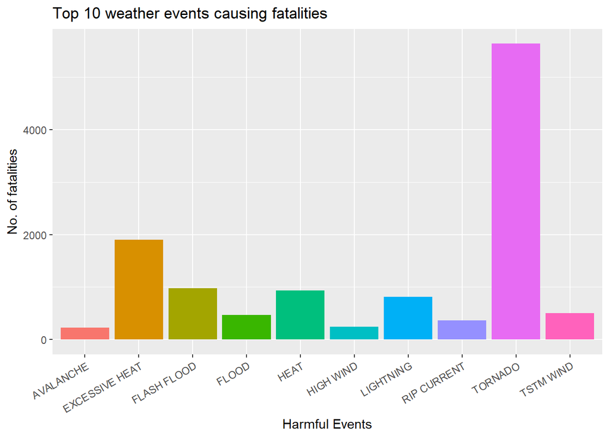

```r
fatalitiesPlot <- ggplot() + geom_bar(data = fatalities[1:10,], aes(x = EVTYPE,
    y = totalFatalities, fill = interaction(totalFatalities, EVTYPE)), stat = "identity",
    show.legend = F) + theme(axis.text.x = element_text(angle = 30, hjust = 1)) +
    xlab("Harmful Events") + ylab("No. of fatalities") + ggtitle("Top 10 weather events causing fatalities") +
    theme(axis.text.x = element_text(angle = 30, hjust = 1))
print(fatalitiesPlot)
```

**We can see that Tornado is responsible of most fatalities.**

The top 10 events with the highest total injuries are shown below

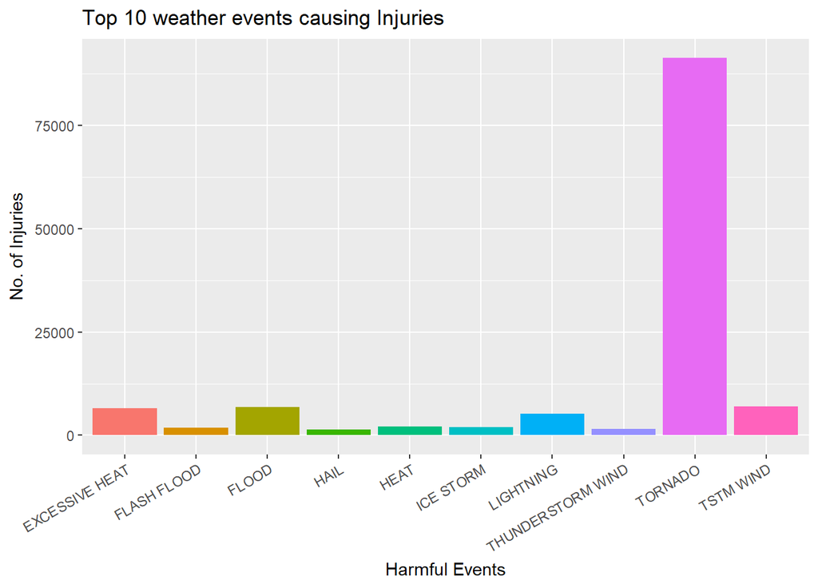

```r
injuriesPlot <- ggplot() + geom_bar(data = injuries[1:10,], aes(x = EVTYPE, y = totalInjuries,
    fill = interaction(totalInjuries, EVTYPE)), stat = "identity", show.legend = F) +
    theme(axis.text.x = element_text(angle = 30, hjust = 1)) + xlab("Harmful Events") +
    ylab("No. of Injuries") + ggtitle("Top 10 weather events causing Injuries") +
    theme(axis.text.x = element_text(angle = 30, hjust = 1))
print(injuriesPlot)
```

**We can see that Tornado is responsible of most injuries.**

### Across the United States, which types of events have the greatest economic consequences?

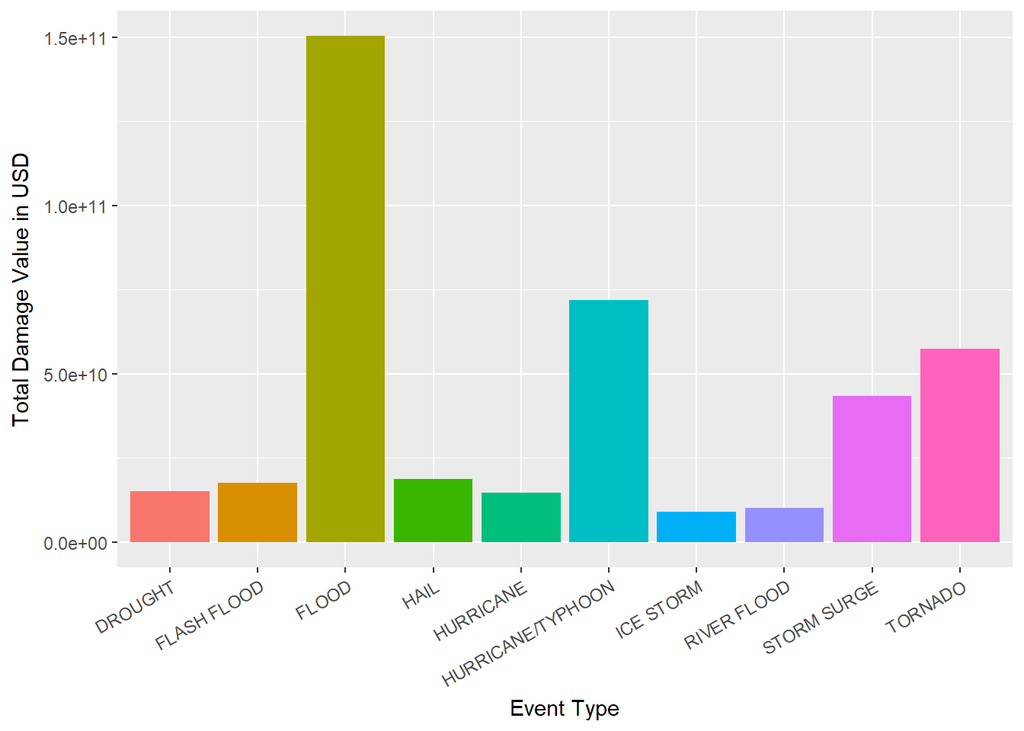

```r
economicalPlot<-ggplot() + geom_bar(data = economical[1:10,], aes(x = EVTYPE, y = TOTALDMGEVENTTYPE, fill = interaction(TOTALDMGEVENTTYPE,
    EVTYPE)), stat = "identity", show.legend = F) + theme(axis.text.x = element_text(angle = 30,
    hjust = 1)) + xlab("Event Type") + ylab("Total Damage Value in USD")
print(economicalPlot)
```

**We can see that Flood is responsible of highest economical impact.**

## Conclusion

Our study shows that Tornados are the most harmful and have the biggest number of fatalities and injuries while Floods have the greatest economic consequences on buildings and crops.